# Metaplots using metadata

Alex Albright

June 28 2021

# Getting NBER metadata

NBER folks recommend downloading [this .tab file](https://data.nber.org/nber-wp-logs/working_papers.tab).

You can also download NBER metadata as .txt files from [here](https://www2.nber.org/wp_metadata). (The issue with the .txt files is that they often are missing dates, which I want for a lot of plots.)

I’ll use the tab file and then use the authors text file for when I get into author demographics.

I `fread` directly from the NBER URLs. I’m doing this on 6/28/21, but if you’re running this later, the output will be slightly different since more papers will be included in the raw data.

```r
library(data.table);library(predictrace);library(tidyverse);library(tidyr)
library(tidytext);library(quickpalette);library(viridis)
library(usmap);library(socviz)
library(ggraph);library(igraph)
library(lubridate);library(patchwork)

nber<-fread("https://data.nber.org/nber-wp-logs/working_papers.tab",  quote = "")%>%
  filter(abstract!="NULL")
```

[output not shown]

[output cut: 3744 more lines]

[output not shown]

```r
nber%>%select(paper)%>%distinct()%>%nrow()
```

```
[1] 30488
```

There are 30,488 papers in the NBER data.

# Most popular words in economics papers?

```r
paper_words <- nber %>%
  unnest_tokens(word, abstract) %>%
  filter(!word %in% stop_words$word)%>%
  count(word, sort = TRUE)%>%
  slice_max(n, n = 10)

tot<-nrow(nber)

paper_words%>%mutate(tot=tot)%>%
  mutate(`fraction of papers`=round(n/tot,2))%>%select(1,4)%>%knitr::kable("markdown")
```

| word | fraction of papers |
| --- | --- |
| model | 0.54 |
| paper | 0.53 |
| data | 0.49 |
| market | 0.39 |
| effects | 0.38 |
| policy | 0.34 |
| rate | 0.31 |
| income | 0.31 |
| firms | 0.30 |
| tax | 0.29 |

# Data vs models?

I use the same word searches as [Currie, Kleven, and Zwiers (2020)](https://www.aeaweb.org/articles?id=10.1257/pandp.20201058).[^1]

```r
nber<-nber%>%
  mutate(ex=(str_detect(abstract, "exploit")),
         dd=str_detect(abstract, "Difference in Diff|Difference in diff|difference in diff|Difference-in-Diff|Difference-in-diff|difference-in-diff|Differences in Diff|Differences in diff|differences in diff|Differences-in-Diff|Differences-in-diff|differences-in-diff|diff-in-diff|d-in-d|DiD"),
         event=str_detect(abstract, "event study|event-study"),
         iv=str_detect(abstract, "Instrumental Variable|Instrumental variable|instrumental variable|Instrumental-Variable|Instrumental-variable|instrumental-variable|Two Stage Least Squares|Two stage least squares|two
stage least squares|2SLS|TSLS|valid instrument|exogenous instrument|IV Estimat|IV estimat|IV-estimat|IV Specification|IV specification|IV-specification|IV Regression|IV regression|IV-regression|IV Strateg|IV strateg|IV-strateg|we instrument|I instrument|paper instruments|exclusion restriction|weak first stage|simulated instrument"),
        rd=str_detect(abstract, "Regression Discontinuit|Regression discontinuit|regression discontinuit|Regression-discontinuity|regression-discontinuity|Regression Kink|Regression kink|regression kink|RD Design|RD design|RD-design|RD Estimat|RD estimat|RD-estimat|RD Model|RD model|RD-model|RD Regression|RD regression|RD-regression|RD Coefficient|RD coefficient|RD-coefficient|RK Design|RK design|RK-Design|RK-design|RKD"),
         data=str_detect(abstract, "data"),
         model=str_detect(abstract, "model"))
```

Note: I use the {ggtext} package to color words in the title and subtitle.

```r
library(ggtext)

nber%>%mutate(year=year(ymd(public_date)))%>%
  group_by(year)%>%filter(year>=1980)%>%
  summarise(data=mean(data==T),
            model=mean(model==T))%>%
  pivot_longer(2:3)%>%
  ggplot(aes(x=year, y=value, color=name, linetype=name, shape=name))+
  geom_line()+geom_point()+
  scale_color_manual(values=c("#009E73", "gray40"), name="")+
  labs(x="", y="", caption="Data: NBER working paper metadata. Plot: Alex Albright.",
       title="<span style = 'font-size:22pt'><span style = 'color:#009E73;'>Data</span> has overtaken <span style = 'color:gray40;'>Models</span></span><br> % of abstracts including the words <span style = 'color:#009E73;'>'data'</span> or <span style = 'color:gray40;'>'model'</span>")+
  scale_y_continuous(labels=scales::percent_format(accuracy = 1), breaks=seq(0.2,.6,.1), limits=c(0.18,0.5))+
  theme_minimal(base_family = "Palatino", base_size = 14)+theme(plot.title.position = "plot", legend.position = "none",
                                                                plot.title = element_markdown())
```

```
 21 failed to parse.
```

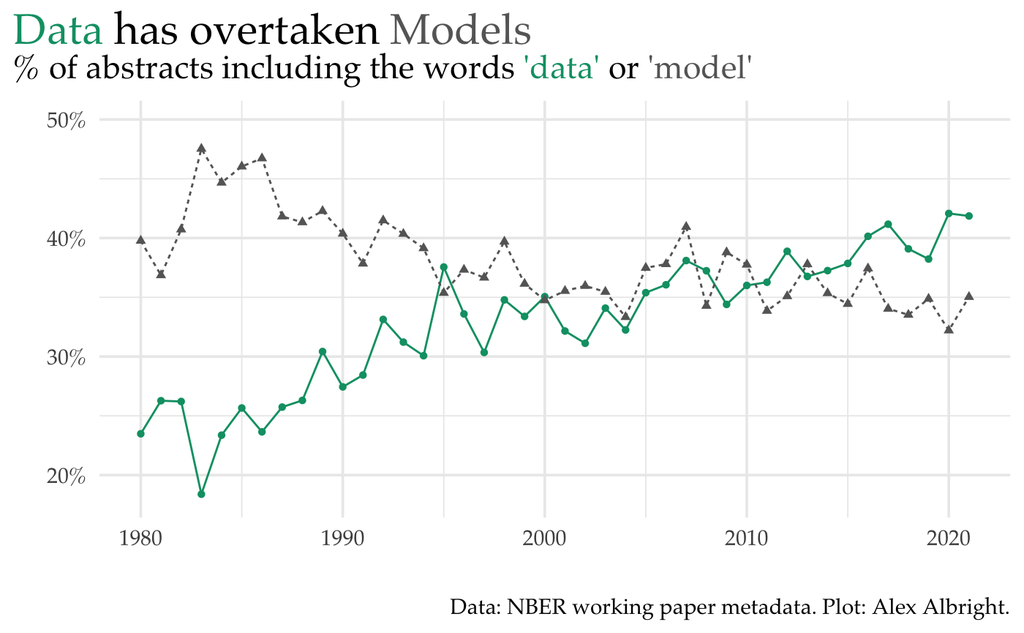

```r
ggsave('graphs/modelvdata1.png', dpi=250, width=7, height=5)
```

# Most popular quasi experimental methods?

```r
library(wesanderson)

nber%>%mutate(year=year(ymd(public_date)))%>%
  group_by(year)%>%filter(year>=1980)%>%
  summarise(IV=mean(iv==T),
            DD=mean(dd==T),
            RD=mean(rd==T))%>%
  pivot_longer(2:4)%>%
  ggplot(aes(x=year, y=value, color=name, linetype=name, shape=name))+
  labs(y="", x="", caption="Data: NBER working paper metadata. Plot: Alex Albright.")+
  geom_point()+
  scale_y_continuous(labels=scales::percent_format(accuracy = 1))+
  geom_line()+ggtitle("DD overtakes IV as quasi-experimental queen",
                      subtitle="% of abstracts using quasi-experimental method words")+
  scale_color_manual(values=wes_palette("Darjeeling1", 4, type="discrete"))+
  theme_minimal(base_family = "Palatino", base_size=15)+
  theme(plot.title.position = "plot", legend.title = element_blank(),
        legend.position = "right")
```

```
 21 failed to parse.
```

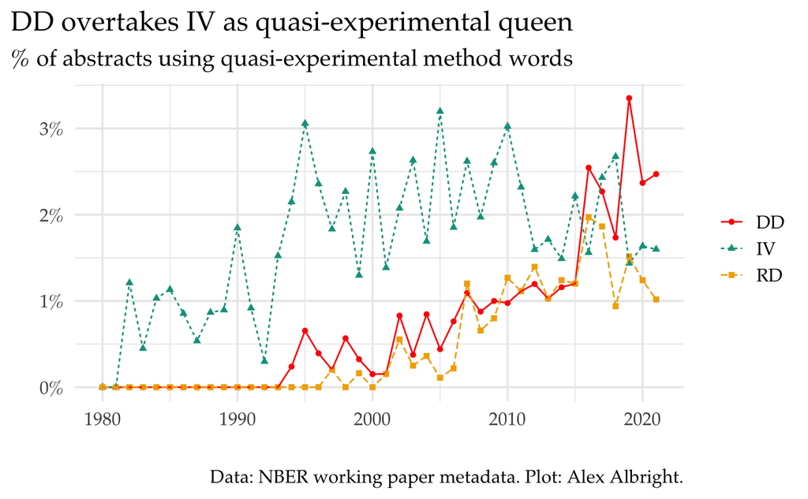

```r
ggsave('graphs/quasi-exp-methods1.png', dpi=250, width=7.5, height=5)
```

# Using the word ‘exploit’

For more n-gram examples see [Text Mining with R](https://www.tidytextmining.com/ngrams.html)

```r
time<-nber%>%mutate(year=year(ymd(public_date)))%>%
  group_by(year)%>%filter(year>=1980)%>%
  summarise(exp=mean(ex==T))%>%
  ggplot(aes(x=year, y=exp))+
  geom_line()+geom_point()+
  geom_line()+ggtitle("% abstracts that use the word 'exploit'")+labs(x="", y="")+
  scale_y_continuous(labels=scales::percent_format(accuracy = 1), breaks=seq(0,.08,.02), limits=c(0,0.08))+
  theme_minimal(base_family = "Palatino", base_size = 14)+theme(plot.title.position = "plot")
```

```
 21 failed to parse.
```

```r
abs_bi <- nber %>%
  unnest_tokens(bigram, abstract, token = "ngrams", n = 3)

abs_bi%>%
  count(bigram, sort = TRUE)
```

| bigram | n |
| --- | --- |
| we find that | 6314 |
| we show that | 3391 |
| in this paper | 2686 |
| the effects of | 2539 |
| the united states | 2384 |
| as well as | 2210 |
| the impact of | 2184 |
| the effect of | 2050 |
| this paper we | 2029 |
| find that the | 1692 |

[output cut: 990 more lines]

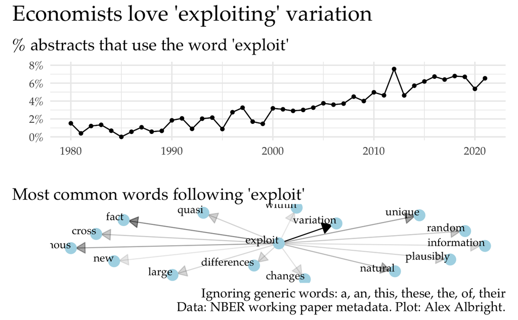

```r
bigrams_separated <- abs_bi %>%
  separate(bigram, c("word1", "word2", "word3"), sep = " ")

bigrams_filtered <- bigrams_separated %>%
  filter(str_detect(word1, "exploit"))

# new bigram counts:
bigram_counts <- bigrams_filtered %>%
  mutate(word1="exploit")%>%
  mutate(word2=if_else(word2=="the"|word2=="an"|word2=="a"|word2=="this"|word2=="of"|word2=="these"|word2=="their", word3, word2))%>%
  select(word1, word2)%>%
  count(word1, word2, sort = TRUE)

bigram_graph <- bigram_counts %>%
  filter(n >= 15) %>%
  graph_from_data_frame()

set.seed(2020)
a <- grid::arrow(type = "closed", length = unit(.15, "inches"))

net<-ggraph(bigram_graph, layout = "fr") +
  geom_edge_link(aes(edge_alpha = n), show.legend = FALSE,
                 arrow = a, end_cap = circle(.07, 'inches')) +
  geom_node_point(color = "lightblue", size = 5) +
  geom_node_text(aes(label = name, family="Palatino"), vjust = 0, hjust = 1) +
  theme_void(base_family = "Palatino", base_size = 14)+
  ggtitle("Most common words following 'exploit'")+
  theme(plot.title.position = "plot")

time/net+
  plot_annotation(title = "Economists love 'exploiting' variation",
                    theme = theme(plot.title = element_text(size = 22, family="Palatino"))) +
  plot_annotation(caption = 'Ignoring generic words: a, an, this, these, the, of, their\nData: NBER working paper metadata. Plot: Alex Albright.',
                    theme = theme(plot.caption = element_text(size = 13, family="Palatino")))


ggsave('graphs/econ-exploit1.png', dpi=250, width=9, height=9)
```

# Econ paper title conventions

```r
nber$q=if_else(grepl("\\?", nber$title), 1, 0)
```

```
input string 109 is invalid in this localeinput string 173 is invalid in this localeinput string 177 is invalid in this localeinput string 183 is invalid in this localeinput string 245 is invalid in this locale
```

```r
nber$colon=if_else(grepl("\\:", nber$title), 1, 0)
```

```
input string 109 is invalid in this localeinput string 173 is invalid in this localeinput string 177 is invalid in this localeinput string 183 is invalid in this localeinput string 245 is invalid in this locale
```

```r
nber%>%summarise(`title w/ question`=mean(q==1),
                  `title w/ colon`=mean(colon==1),
                 `title w/ question or colon`=mean(q==1 | colon==1),
                  `title w/ question and colon`=mean(q==1 & colon==1))%>%
  pivot_longer(1:4)%>%mutate(value=round(value,2))%>%
  rename(convention=name, `fraction of papers`=value)%>%knitr::kable("markdown")
```

| convention | fraction of papers |
| --- | --- |
| title w/ question | 0.13 |
| title w/ colon | 0.34 |
| title w/ question or colon | 0.45 |
| title w/ question and colon | 0.03 |

34% use :s and 13% use question marks! 45% do one of the two.

# Common bigrams

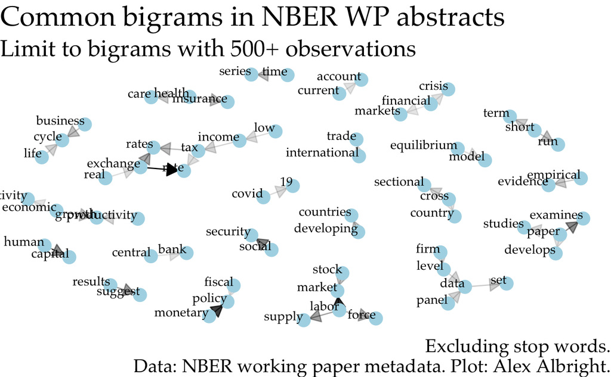

```r
abs_bi <- nber %>%
  unnest_tokens(bigram, abstract, token = "ngrams", n = 2)

bigrams_separated <- abs_bi %>%
  separate(bigram, c("word1", "word2"), sep = " ")

bigrams_filtered <- bigrams_separated %>%
  filter(!word1 %in% stop_words$word) %>%
  filter(!word2 %in% stop_words$word)

# new bigram counts:
bigram_counts <- bigrams_filtered %>%
  count(word1, word2, sort = TRUE)

#make graph
bigram_graph <- bigram_counts %>%
  filter(!is.na(word1))%>%
  filter(n >= 500) %>%
  graph_from_data_frame()

set.seed(2020)
a <- grid::arrow(type = "closed", length = unit(.15, "inches"))

ggraph(bigram_graph, layout = "fr") +
  geom_edge_link(aes(edge_alpha = n), show.legend = FALSE,
                 arrow = a, end_cap = circle(.07, 'inches')) +
  geom_node_point(color = "lightblue", size = 5) +
  geom_node_text(aes(label = name, family="Palatino"), vjust = 0, hjust = 1) +
  theme_void()+
  ggtitle("Common bigrams in NBER WP abstracts", subtitle="Limit to bigrams with 500+ observations")+
  labs(caption="Excluding stop words.\nData: NBER working paper metadata. Plot: Alex Albright.")+
  theme(text=element_text(family="Palatino", size = 20))

ggsave('graphs/bigrams1.png', dpi=250, width=10.3, height=7)
```

# Who are the authors?

Use [this {predict race}](https://cran.r-project.org/web/packages/predictrace/vignettes/Predict-race-of-surname.html) package from Jacob Kaplan to get race and gender from the author names.

Let’s use the cleaner author .txt data but only keep those that link to the large .tab file, so we are pulling from the same universe of papers.

```r
auths<-fread("http://www2.nber.org/wp_metadata/txt/auths.txt", quote = "")
papers<-nber%>%select(paper, public_date)%>%distinct()
authors<-inner_join(auths, papers)
```

There are 68,247 author-paper observations.

```r
#separate out name into first and last
authors<-authors%>%
  mutate(lastname=word(name, -1), firstname=word(name, -2))
```

```
argument is not an atomic vector; coercingargument is not an atomic vector; coercing
```

```r
df<-authors%>%
  mutate(firstname_race=predict_race(firstname, probability = F, surname = F)$likely_race,
         lastname_race=predict_race(lastname, probability = F, surname = T)$likely_race,
         gender=predict_gender(firstname, probability = F)$likely_gender)
```

Make plots.

```r
library(lubridate)

# RACE

dfr<-df%>%mutate(year=year(ymd(public_date)))%>%filter(year>=1980)%>%
  group_by(year)%>%filter(!is.na(gender) & !is.na(lastname_race))%>%
  summarise(`White`=mean(lastname_race=="white"),
            `Black`=mean(lastname_race=="black"),
            `Asian`=mean(lastname_race=="asian"),
            `Hispanic`=mean(lastname_race=="hispanic"),
            `Native`=mean(lastname_race=="american indian"))%>%pivot_longer(2:6)
```

```
 38 failed to parse.
```

```r
race<-dfr%>%ggplot(aes(x=year, y=value, fill=name))+
  geom_area()+scale_fill_manual(values=c("#A6CEE3", "#B2DF8A", "#F89A99", "#FABF6F", "#CAB2D6"), name="")+
  scale_y_continuous(labels=scales::percent)+theme_minimal(base_family = "Palatino")+
  theme(plot.title.position = "plot")+
  ggtitle("Race* of NBER Paper Authors")+
  labs(x="", y="", caption="*Predicted from last name using Census data.\nOmitting authors without predictions.")

#GENDER

dfg<-df%>%mutate(year=year(ymd(public_date)))%>%filter(year>=1980)%>%
  group_by(year)%>%filter(!is.na(gender) & !is.na(lastname_race))%>%
  summarise(`Men`=mean(gender=="male"),
            `Women`=mean(gender=="female"))%>%pivot_longer(2:3)
```

```
 38 failed to parse.
```

```r
gender<-dfg%>%ggplot(aes(x=year, y=value, fill=name))+
  geom_area()+scale_fill_manual(values=c("gray80", "gray30"), name="")+
  scale_y_continuous(labels=scales::percent)+theme_minimal(base_family = "Palatino")+
  theme(plot.title.position = "plot")+
  ggtitle("Gender* of NBER Paper Authors")+
  labs(x="", y="", caption="*Predicted from first name using\n US Social Security Admin Data.\nOmitting authors without predictions.")

#GENDER AND RACE

dfgr<-df%>%mutate(year=year(ymd(public_date)))%>%filter(year>=1980)%>%
  group_by(year)%>%filter(!is.na(gender) & !is.na(lastname_race))%>%
  summarise(`White Men`=mean(gender=="male" & lastname_race=="white"),
            `White Women`=mean(gender=="female" & lastname_race=="white"),
            `Black Women`=mean(gender=="female" & lastname_race=="black"),
            `Black Men`=mean(gender=="male" & lastname_race=="black"),
            `Asian Women`=mean(gender=="female" & lastname_race=="asian"),
            `Asian Men`=mean(gender=="male" & lastname_race=="asian"),
            `Hispanic Women`=mean(gender=="female" & lastname_race=="hispanic"),
            `Hispanic Men`=mean(gender=="male" & lastname_race=="hispanic"),
            `Native Women`=mean(gender=="female" & lastname_race=="american indian"),
            `Native Men`=mean(gender=="male" & lastname_race=="american indian"))%>%pivot_longer(2:11)
```

```
 38 failed to parse.
```

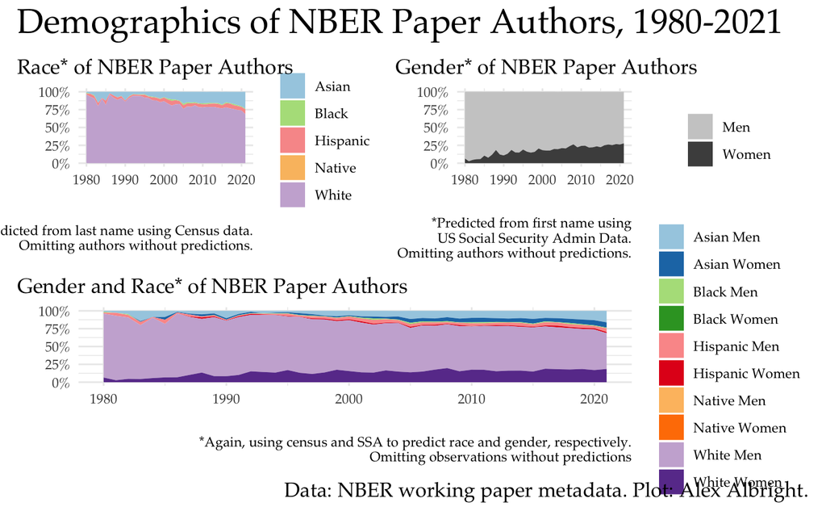

```r
rg<-dfgr%>%ggplot(aes(x=year, y=value, fill=name))+
  geom_area()+scale_fill_brewer(palette="Paired", name = "")+
  scale_y_continuous(labels=scales::percent)+theme_minimal(base_family = "Palatino")+theme(plot.title.position = "plot")+
  ggtitle("Gender and Race* of NBER Paper Authors")+
  labs(x="", y="", caption="*Again, using census and SSA to predict race and gender, respectively.\nOmitting observations without predictions")

#Put them all together

(race+gender)/rg+plot_annotation(title = 'Demographics of NBER Paper Authors, 1980-2021',
                    theme = theme(plot.title = element_text(size = 22, family="Palatino"))) +
  plot_annotation(caption = 'Data: NBER working paper metadata. Plot: Alex Albright.',
                    theme = theme(plot.caption = element_text(size = 13, family="Palatino")))


ggsave('graphs/authors-nber1.png', dpi=250, width=8, height=8)
```

# Where do econs write about?

Not a lot of counties mentioned. Focus on US states.

```r
paper_words <- nber %>%
  unnest_tokens(word, abstract) %>%
  count(word, sort = TRUE)

states<-election%>%select(state)%>%
  mutate(state=tolower(state))%>%distinct()%>%
  filter(state!="district of columbia")

df<-paper_words%>%
  filter(word %in% states$state)%>%mutate(state=word)

paper_2words <- nber %>%
  unnest_tokens(bigram, abstract, token = "ngrams", n = 2)%>%
  count(bigram, sort = TRUE)

df2<-paper_2words%>%
  filter(bigram %in% states$state)%>%mutate(state=bigram)

dff<-bind_rows(df, df2)
```

plot count and count per million in population

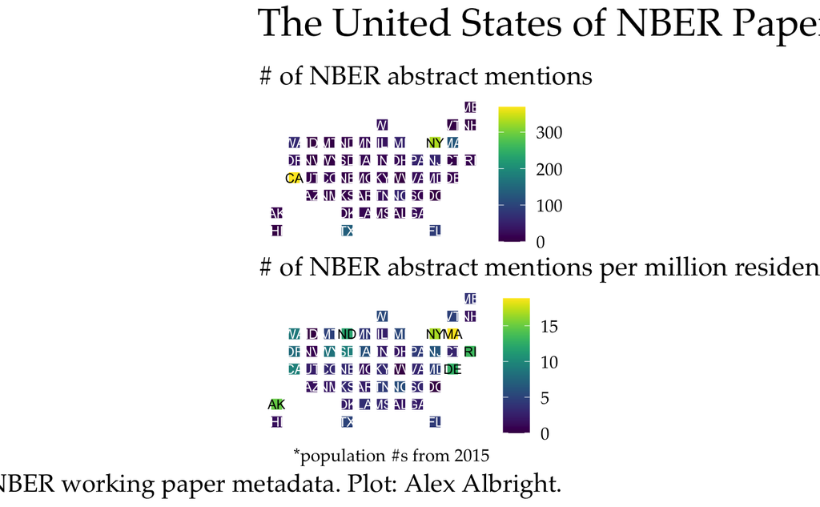

```r
statepop$state<-tolower(statepop$full)
dff<-full_join(dff, statepop)
dff<-dff%>%
  mutate(n=replace_na(n, 0))%>%
  mutate(popm=pop_2015/1000000)%>%
  mutate(nperm=n/popm)

library(statebins)
#the united states of nber papers

a<-statebins(state_data = dff, state_col = "full", value_col = "n",
          ggplot2_scale_function = viridis::scale_fill_viridis)+
  theme_void(base_family = "Palatino", base_size = 14)+ theme(legend.title = element_blank())+
  ggtitle("# of NBER abstract mentions")

b<-statebins(state_data = dff, state_col = "full", value_col = "nperm",
          ggplot2_scale_function = viridis::scale_fill_viridis)+
  theme_void(base_family = "Palatino", base_size = 14)+ theme(legend.title = element_blank())+ #plot.title = element_text(hjust = 0.5))+
  ggtitle("# of NBER abstract mentions per million residents*")+
  labs(caption="*population #s from 2015")

library(patchwork)
a/b+
  plot_annotation(title = 'The United States of NBER Papers',
                    theme = theme(plot.title = element_text(size = 25, family="Palatino"))) +
  plot_annotation(caption = 'Data: NBER working paper metadata. Plot: Alex Albright.',
                    theme = theme(plot.caption = element_text(size = 16, family="Palatino")))


ggsave('graphs/states-nber1.png', dpi=250, width=7, height=10)
```

[^1]: See Table A.I. in their online appendix.